# Interactive Charts: htmlwidgets

November 6, 2015

## This presentation

- Presentation: http://patilv.com/INRUG-InteractiveCharts
- Single page version of this presentation: http://patilv.com/INRUG-InteractiveCharts/allinone.html
- Created using R markdown and R-Studio
- GitHub repository for source : https://github.com/patilv/INRUG-InteractiveCharts

## htmlwidgets, rCharts

- `htmlwidgets`: Ramnath Vaidyanathan, Kenton Russell, and RStudio
- `rCharts` (a transition to 2.0 using `htmlwidgets` is underway): Ramnath Vaidyanathan
- Provide the ability, from within R, to create, customize and publish interactive JavaScript (JS) visualizations
- JS is a computer programming language that can create interactivity using web browsers
- There are many pre-written JS libraries that make the process of creating visualizations easier.

```r
install.packages("htmlwidgets")
```

## Challenge in learning

- Different JS libraries developed independently - consistency in calls can at times be a challenge
- Customization for specific needs may require writing JS code

### Learning approach

- Follow examples, questions, and issues presented in different venues
- Stick to few JS libraries which provide many choices of charts and become very familiar with them. Don't forget that few have restrictions for commercial use.

## A sampling of the several htmlwidget packages

| Interactive tables | [DT](https://rstudio.github.io/DT/), [formattable](http://renkun.me/formattable/),datacomb, rpivotTable, [rhandsontable](http://jrowen.github.io/rhandsontable/), D3TableFilter, sortableR |
| --- | --- |
| Heatmaps | d3heatmap |
| Dimple | rcdimple |
| Tau Charts | taucharts |
| Metrics Graphics | [metricsgraphics](http://hrbrmstr.github.io/metricsgraphics/) |
| Bokeh | [rbokeh](http://hafen.github.io/rbokeh/) |

## Few more sample packages

| streamgraph | [streamgraph](http://hrbrmstr.github.io/streamgraph/) |
| --- | --- |
| Scatterplot matrices | pairsD3, scatterMatrixD3 |
| Pan and Zoom graphs | svgPanZoom |
| Parallel Coordinate Charts | parcoords |
| Sequences Sunburst | [sunburstR](http://www.buildingwidgets.com/blog/2015/7/2/week-26-sunburstr) |

## Example 1: Interactive table

```r
library(htmlwidgets)
suppressPackageStartupMessages(library(dplyr))
library(DT)# if (!require("DT")) install.packages('DT')
dt=datatable(iris, options=list(pageLength = 5))
saveWidget(dt,file = "dt.html",selfcontained = TRUE)
```

[interactive chart not shown]

## Example 2: Heatmap

```r
head(mtcars)
```

|  | mpg | cyl | disp | hp | drat | wt | qsec | vs | am | gear | carb |
| --- | --- | --- | --- | --- | --- | --- | --- | --- | --- | --- | --- |
| Mazda RX4 | 21.0 | 6 | 160 | 110 | 3.90 | 2.620 | 16.46 | 0 | 1 | 4 | 4 |
| Mazda RX4 Wag | 21.0 | 6 | 160 | 110 | 3.90 | 2.875 | 17.02 | 0 | 1 | 4 | 4 |
| Datsun 710 | 22.8 | 4 | 108 | 93 | 3.85 | 2.320 | 18.61 | 1 | 1 | 4 | 1 |
| Hornet 4 Drive | 21.4 | 6 | 258 | 110 | 3.08 | 3.215 | 19.44 | 1 | 0 | 3 | 1 |
| Hornet Sportabout | 18.7 | 8 | 360 | 175 | 3.15 | 3.440 | 17.02 | 0 | 0 | 3 | 2 |
| Valiant | 18.1 | 6 | 225 | 105 | 2.76 | 3.460 | 20.22 | 1 | 0 | 3 | 1 |

## Example 2 continued: Heatmap

```r
library(d3heatmap)#if (!require("d3heatmap")) devtools::install_github("rstudio/d3heatmap")
myheatmap=d3heatmap(mtcars,scale="column")
saveWidget(myheatmap,file = "myheatmap.html",selfcontained = TRUE)
```

## Example 2 continued: Heatmap

[interactive chart not shown]

## Example 3: `rcdimple`: Many graph types available

[See examples of different types here.](http://patilv.com/rcdimpleexamples/)

```r
suppressPackageStartupMessages(library(rcdimple)) # demo(dimple) for tons of examples#if (!require("rcdimple")) devtools::install_github("timelyportfolio/rcdimple")
myirisplot=iris%>% dimple(x = "Sepal.Length",
  y = "Sepal.Width",
  groups = "Species",
  type = "bubble",width=600,height=380)%>% yAxis( overrideMin = 2)%>%
  add_legend()
saveWidget(myirisplot,file = "myirisplot.html",selfcontained = TRUE)
```

## Example 3 continued

[interactive chart not shown]

## Example 4 grouped bar

```r
gearam=mtcars%>%group_by(gear,am)%>%summarise(count=length(gear))
gearam$am<-ifelse(gearam$am==0,yes= "Auto",no= "Manual")
gearam
```

| gear | am | count |
| --- | --- | --- |
| 3 | Auto | 15 |
| 4 | Auto | 4 |
| 4 | Manual | 8 |
| 5 | Manual | 5 |

## Example 4 grouped bar: `rcdimple`: Many graph types available

```r
mydimplebarplot=gearam%>%dimple(
    x = c("gear","am"), y = "count",
    groups = "am", type = "bar",width=600,height=390)%>%
   add_legend()
saveWidget(mydimplebarplot,file = "mydimplebarplot.html",selfcontained = TRUE)
```

## Example 4 continued

[interactive chart not shown]

## Example 5: `taucharts`: Many graph types

```r
library(taucharts)#if (!require("taucharts")) devtools::install_github("hrbrmstr/taucharts")
tauirisplot=iris %>% tauchart(height=500,width=800)%>%
  tau_point(x="Sepal.Length",y="Sepal.Width",color="Species")%>%
  tau_tooltip(c("Sepal.Length", "Sepal.Width", "Species"))%>%
  tau_guide_y(auto_scale=FALSE)%>%
  tau_guide_x(auto_scale=FALSE)%>%tau_legend()
saveWidget(tauirisplot,file = "tauirisplot.html",selfcontained = TRUE)
```

## Example 5 continued

[interactive chart not shown]

## Example 6: `taucharts`: Many graph types

```r
gearam$gear=as.factor(gearam$gear)
gearbartauplot=tauchart(gearam)%>%tau_bar("gear","count","am")%>%
  tau_tooltip(c("gear", "am", "count"))%>% tau_legend()
saveWidget(gearbartauplot,file = "gearbartauplot.html",selfcontained = TRUE)
```

## Example 6 continued

[interactive chart not shown]

## Example 7: `metricsgraphics`: Many graph types available

Scatter and line plots (time-series data), grids/facets of graphs, and connected graphs

```r
#if (!require("metricsgraphics")) devtools::install_github("hrbrmstr/metricsgraphics")
library(metricsgraphics)
irismetricsplot=iris %>% mjs_plot(x=Sepal.Length,y=Sepal.Width) %>%
  mjs_point(color_accessor=Species, color_type="category")%>%
    mjs_labs(x="Sepal.Length", y="Sepal.Width")%>%
    mjs_axis_y(min_y=2)
saveWidget(irismetricsplot,file = "irismetricsplot.html",selfcontained = TRUE)
```

## Example 7 continued

[interactive chart not shown]

## Example 8: `rbokeh`: Many graph types available

http://hafen.github.io/rbokeh/: Bar missing

```r
library(rbokeh)#if (!require("rbokeh")) devtools::install_github("bokeh/rbokeh")
bokehirisplot=figure() %>%
  ly_points(Sepal.Length, Sepal.Width, data = iris,
    color = Species,
    hover = list(Sepal.Length, Sepal.Width))
saveWidget(bokehirisplot,file = "bokehirisplot.html",selfcontained = TRUE)
```

## Example 8 continued

[interactive chart not shown]

## Example 9: Scatter plot matrix `pairsD3`

```r
#if (!require("pairsD3")) devtools::install_github("garthtarr/pairsD3")
library(pairsD3)
pairsd3plot=pairsD3(iris[,1:4],group=iris[,5])#%>%savePairs(file = 'iris.html')
saveWidget(pairsd3plot,file = "pairsd3plot.html",selfcontained = TRUE)
```

## Example 9 continued

[interactive chart not shown]

## Example 10: Scatter plot matrix `scatterMatrixD3`

```r
#if (!require("scatterMatrixD3")) devtools::install_github("jcizel/scatterMatrixD3")
library(scatterMatrixD3)
scattermatplot=scatterMatrix(
   data = iris
)
saveWidget(scattermatplot,file = "scattermatplot.html",selfcontained = TRUE)
```

## Example 10 continued

[interactive chart not shown]

## Example 11 `streamgraph`

```r
#if (!require("streamgraph")) devtools::install_github("hrbrmstr/streamgraph")
library(streamgraph)
library(babynames)
head(babynames,3)
maryplot=babynames %>%
  filter(grepl("^Mar", name)) %>%
  group_by(year, name) %>%
  tally(wt=n) %>%
  streamgraph("name", "n", "year")
saveWidget(maryplot,file = "maryplot.html",selfcontained = TRUE)
```

[output not shown]

## Example 11 continued

[interactive chart not shown]

## Example 12 `svgPanZoom`

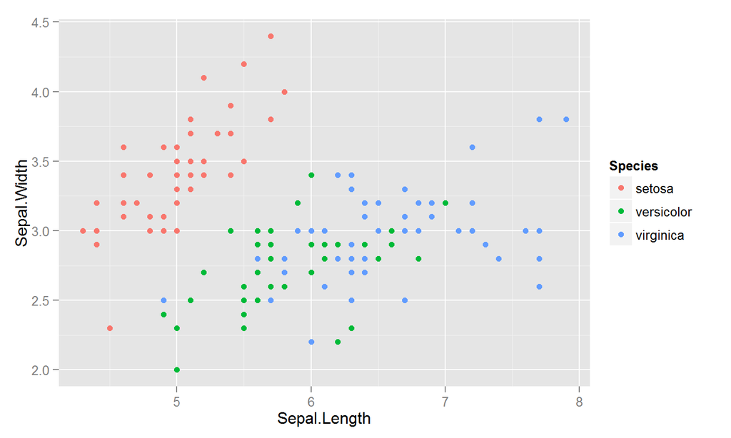

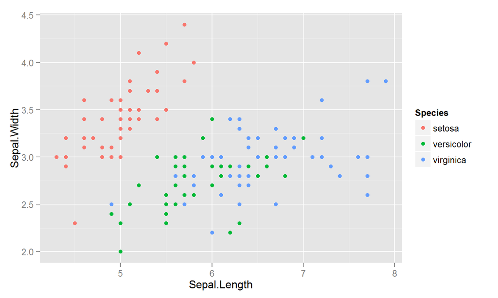

```r
#if (!require("svgPanZoom")) devtools::install_github("timelyportfolio/svgPanZoom")
library(svgPanZoom)
library(ggplot2)
mynewggplot=svgPanZoom(
  ggplot(iris,aes(Sepal.Length,Sepal.Width,color=Species))+geom_point()
)
```

```r
saveWidget(mynewggplot,file = "mynewggplot.html",selfcontained = TRUE)
```

## Example 12 continued

[interactive chart not shown]

## Example 13 `parcoords`

```r
#if (!require("parcoords")) devtools::install_github("timelyportfolio/parcoords")
library(parcoords)
mymtcarsplot=parcoords(mtcars,brushMode = "1D-axes-multi")
saveWidget(mymtcarsplot,file = "mymtcarsplot.html",selfcontained = TRUE)
```

## Example 13 continued

[interactive chart not shown]

## Example 14 `sunburstr`

```r
#if (!require("sunburstR")) devtools::install_github("timelyportfolio/sunburstR")
library(sunburstR)
school=read.csv("school.csv")
school
```

[output not shown]

```r
school$combo=paste(school$School,school$Department,school$Specialization,sep="-")
school$combo=gsub("-$","",school$combo)
head(school,1)
```

| School | Department | Specialization | Students | combo |
| --- | --- | --- | --- | --- |
| A&S | Philosophy | Ethics | 30 | A&S-Philosophy-Ethics |

```r
myburst=sunburst(school[,c(5,4)])
saveWidget(myburst,file = "myburst.html",selfcontained = TRUE)
```

## Example 14 continued

[interactive chart not shown]

## More packages

- `leaflet`: Mapping
- Network data and Graph Diagrams
  - mermaid and grViz: [DiagrammeR](http://rich-iannone.github.io/DiagrammeR/index.html)
  - Vivagraph: vivagRaph
  - d3Network: [networkD3](http://christophergandrud.github.io/networkD3/)
  - Circle plot: edgebundleR
  - sigma: sigma,
  - hive: [d3hiveR](http://www.buildingwidgets.com/blog/2015/7/11/week-27-d3hiver)
- `ggvis`
- `googleVis`
- Server based interactivity - `shiny`